# Democratizing Access to Education Data

With the Urban Institute’s Education Data Portal

Erika Tyagi

## The Education Data Portal bridges the gap between **data availability** and **data accessibility**.

1. What do I mean by the availability-accessibility gap?
2. How does the portal bridge this gap?
3. Why does bridging this gap matter?

## What do I mean by the data availability-accessibility gap?

**Example**: Collecting data on COVID in jails and prisons

- An Excel spreadsheet
- Scanned as a PDF
- At an angle
- And a little blurry
- With inconsistent rows and columns
- And dark text on a dark background
- And the occasional coffee spill

**Accessible to whom?**

## How does the portal bridge this gap?

- The portal is a freely available **one-stop-shop** for all major datasets released by government agencies on U.S. schools, school districts, and colleges.
- The portal includes harmonized data and metadata for **100+ datasets** published by 10+ agencies and institutions.
- The portal makes it easier for both technical and non-technical users to look at **trends over time** and combine data **from different sources**.

## How does the portal bridge this gap?

**Example**: How has tuition at my alma mater changed?

[figure not shown]

[figure not shown]

## **Without** the Education Data Portal…

**Example**: How has tuition at my alma mater changed?

- Find the agency collecting this data
- Download data files for each year
- Load each file into R or Python
- Read the data documentation
- Notice a few anomalies
- Re-read the data documentation
- Give up Take an ice cream break
- Update the code per the documentation
- Remember to repeat the process again next year
- (And hope nothing changes)

**This is tedious, error-prone, and simply not fun.**

## Using the portal **R package**…

**Example**: How has tuition at my alma mater changed?

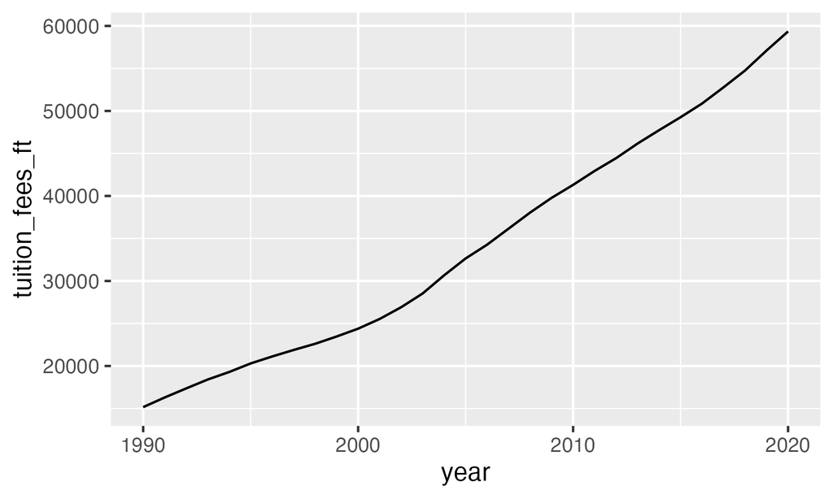

```r
library(educationdata)

# Get data
carleton_data <- get_education_data(
  level = "college-university",
  source = "ipeds",
  topic = "academic-year-tuition",
  filters = list(
    year = c(1990:2020),
    unitid = "173258",
    tuition_type = "4"
  )
)

# Plot data
carleton_data %>%
  ggplot(aes(x = year, y = tuition_fees_ft)) +
  geom_line()
```

## Using the portal **Python package**…

**Example**: How has tuition at my alma mater changed?

[figure not shown]

```python
import educationdata

# Get data
carleton_data = get_education_data(
  level = "college-university",
  source = "ipeds",
  topic = "academic-year-tuition",
  filters = {
    "year": range(1990, 2020),
    "unitid": "173258",
    "tuition_type": "4"
  }
)

# Plot data
carleton_data.plot.line(
  x = "year", y = "tuition_fees_ft"
)
```

## Using the portal **Stata package**…

**Example**: How has tuition at my alma mater changed?

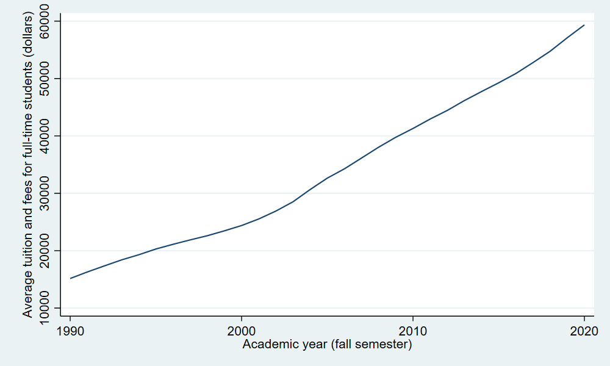

```
* Get data
educationdata ///
  using "college ipeds academic-year-tuition", sub( ///
  year=1990/2020 ///
  unitid=173258 ///
  tuition_type=4 ///
)

* Plot data
twoway (line tuition_fees_ft year)
```

## Using the portal **Data Explorer**…

**Example**: How has tuition at my alma mater changed?

## Using the **summary endpoints**…

**Example**: Have public institutions seen the same trend?

- R
- Python
- Stata
- Data Explorer

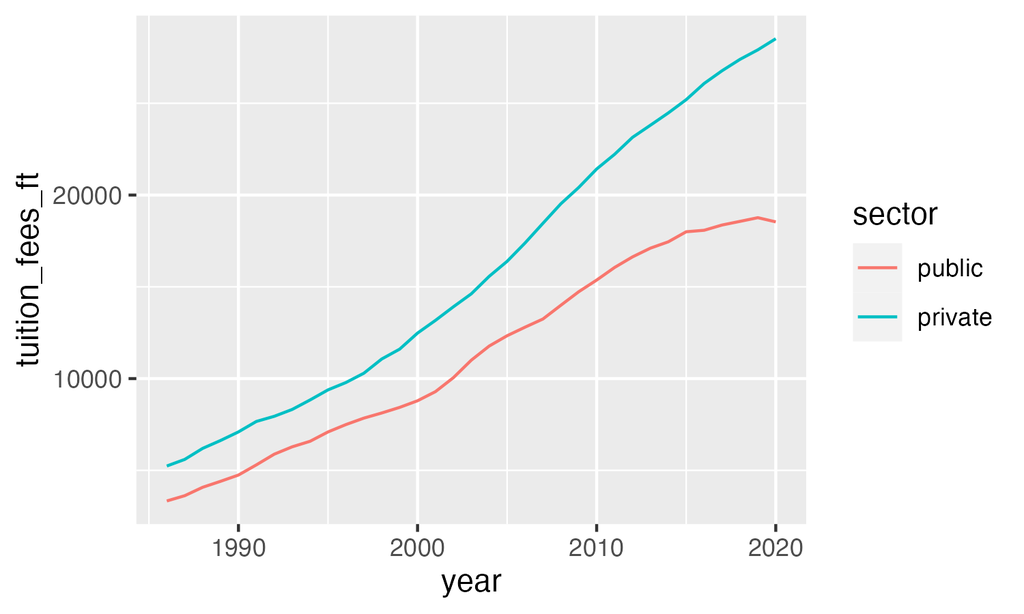

```r
# Get summary data
sector_avg_data <- get_education_data_summary(
  level = "college-university",
  source = "ipeds",
  topic = "academic-year-tuition",
  stat = "avg",
  var = "tuition_fees_ft",
  by = "sector",
  filters = list(
    level_of_study = "1",
    tuition_type = "4",
    sector = "1,2"
  )
)

# Plot data
sector_avg_data %>%
  mutate(sector = factor(sector) %>%
    fct_recode("public" = "1", "private" = "2")) %>%
  ggplot(aes(x = year, y = tuition_fees_ft, group = sector, color = sector)) +
  geom_line()
```

## Why do I think the portal bridges this gap so effectively?

1. By focusing on the **underlying API**
2. By focusing on **data documentation**

## Get in touch

- Access the portal: https://educationdata.urban.org
- Email the portal: educationdata@urban.org
- Email me: etyagi@urban.org

[figure not shown]

https://educationdata.urban.org